# Example

# Example dataset

We demonstrate the use of CSNet with a simulated dataset. The data was simulated based on model (1) with cell-type-specific co-expression networks as in Table 1 & Figure 1 of our paper (https://www.tandfonline.com/doi/full/10.1080/01621459.2023.2297467). In specific, n=600, p=100, cell type 1 is twice as abundant as cell type 2.

```r
library(CSNet)
```

```r
# simulated cell type proportions
dim(sim_data_list$P) # 2 cell types
```

```
#> [1] 600   2
```

```r
# simulated cell-type-specific expression
dim(sim_data_list$ct_X[[1]]) # 600 samples, 100 genes
```

```
#> [1] 600 100
```

```r
dim(sim_data_list$ct_X[[2]])
```

```
#> [1] 600 100
```

## Cell-type-specific co-expression networks

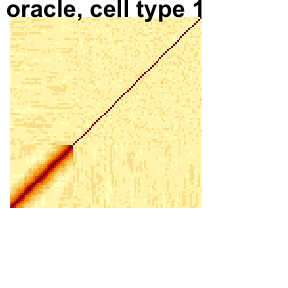

```r
# truncated AR(1) in the first cluster (as in Figure 1 of the paper)
heatmap(cor(sim_data_list$ct_X[[1]]), Rowv = NA, Colv = NA,
        symm = T, scale = 'none', labRow = FALSE, labCol = FALSE,
        main =  'oracle, cell type 1')
```

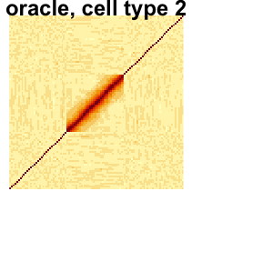

```r
# truncated AR(1) in the second cluster (as in Figure 1 of the paper)
heatmap(cor(sim_data_list$ct_X[[2]]), Rowv = NA, Colv = NA,
        symm = T, scale = 'none',  labRow = FALSE, labCol = FALSE,
        main = 'oracle, cell type 2')
```

These are the ‘oracle’ estimates based on true cell-type-specific expression data. Next, we construct the observed bulk gene expression data and our goal is to use bulk gene expression data to estimate these cell-type-specific networks.

## Bulk co-expression networks

```r
# generate bulk data based on model (1)
bulk_X <- sim_data_list$P[,1] * sim_data_list$ct_X[[1]] +
  sim_data_list$P[,2] * sim_data_list$ct_X[[2]]
```

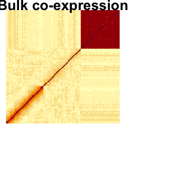

```r
# naive estimates based on bulk gene expression: sample correlations
bulk_cor <- cor(bulk_X)
heatmap(bulk_cor, Rowv = NA, Colv = NA,
        symm = T, scale = 'none',
        labRow = FALSE, labCol = FALSE,
        main = 'Bulk co-expression')
```

The correlation matrix based on bulk sample performs unsatisfactory in estimating cell-type-specific co-expressions. It can be seen that the co-expressions in cell type 2 are much attenuated in the bulk estimate due to its low cell type proportion. Moreover, genes in cluster 3 appear correlated due to the confounding effect of varying cell type proportions.

# Run CSNet

```r
# CSNet takes observed bulk gene expression data and cell type proportions as input
res <- CSNet(X = bulk_X, P = sim_data_list$P)
# res is a list of cell-type-specific co-expression network estimates
```

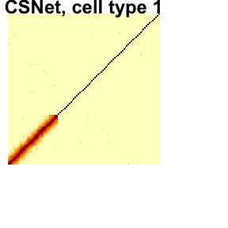

```r
heatmap(res[[1]], Rowv = NA, Colv = NA, symm = T,
        labRow = FALSE, labCol = FALSE, scale = 'none',
        main = 'CSNet, cell type 1')
```

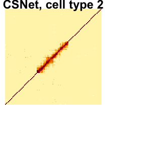

```r
heatmap(res[[2]], Rowv = NA, Colv = NA, symm = T,
        labRow = FALSE, labCol = FALSE, scale = 'none',
         main = 'CSNet, cell type 2')
```

We can see that CSNet estimated the true cell-type-specific co-expression networks well and effectively addressed the confounding effect of cell type proportions.